# Read Doric File

### Install and import library

Install the rhdf5 library by running the next code cell. If the library is already installed, skip to the next code cell.

```r
install.packages("BiocManager");
BiocManager::install("rhdf5");
```

Import the rhdf5 library

```r
library("rhdf5");
```

### Set file path

Edit the following cell with your file path

```r
filename = "Console_Acq_0000.doric";
```

### Print all file tree (optional)

This allows you to identify the path of each dataset of interest and its associated time vector. But Feel free to skip this step, since you can check the file structure in the Doric File Editor of DNS software.

```r
h5ls(filename)
```

|  | group | name | otype | dclass | dim |
| --- | --- | --- | --- | --- | --- |
| 0 | / | Configurations | H5I_GROUP |  |  |
| 1 | /Configurations | FPConsole | H5I_GROUP |  |  |
| 2 | /Configurations/FPConsole | AIN01 | H5I_GROUP |  |  |
| 3 | /Configurations/FPConsole/AIN01 | GraphSettings | H5I_GROUP |  |  |
| 4 | /Configurations/FPConsole/AIN01 | Settings | H5I_GROUP |  |  |
| 5 | /Configurations/FPConsole | AOUT01 | H5I_GROUP |  |  |
| 6 | /Configurations/FPConsole/AOUT01 | GraphSettings | H5I_GROUP |  |  |
| 7 | /Configurations/FPConsole/AOUT01 | Modulations | H5I_GROUP |  |  |
| 8 | /Configurations/FPConsole/AOUT01/Modulations | Modulation1 | H5I_GROUP |  |  |
| 9 | /Configurations/FPConsole/AOUT01 | Settings | H5I_GROUP |  |  |

[output cut: 33 more lines]

Note that when using the Lock-In mode, the photometry demodulated signals have the following path naming: “DataAcquisition/FPConsole/Signals/Series#/AIN#xAOUT#-LockIn/Values” and associated Time vector: “DataAcquisition/FPConsole/Signals/Series#/AIN#xAOUT#-LockIn/Time”

### Load signal

Check the file structure and pick the signals you would like to load. Paste the paths to selected datasets:

```r
signal <- h5read(filename,'/DataAcquisition/FPConsole/Signals/Series0003/AnalogIn/AIN01')
time   <- h5read(filename,'/DataAcquisition/FPConsole/Signals/Series0003/AnalogIn/Time')
```

### Plot loaded signal

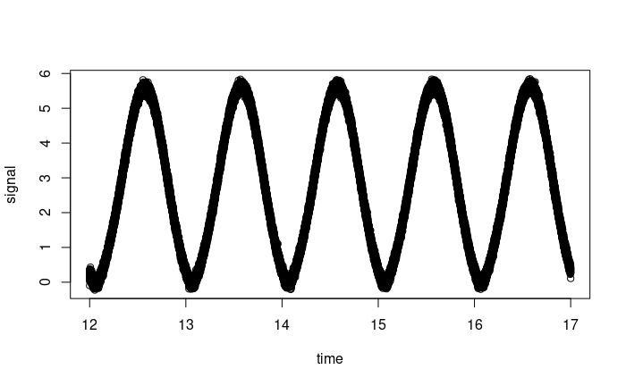

```r
plot(time, signal)
```

Read more about [rhdf5 library](https://www.neonscience.org/resources/learning-hub/tutorials/hdf5-intro-r).